# An Exploratory Analysis of Educational Disparity in the United States

**By:** Kevin Nguyen, originally for MTH448: Data-Oriented Computing

**Created:** 03/02/2023

**Last Updated:** 03/28/2023

## Introduction

The main job of the U.S. Census Bureau, as their name implies, is to gather data about the population and economy of the United States. Towards this end, they conduct surveys of people living in the United States every few years and release this information publicly as part of their transparency goals<sup>1</sup> after removing any personally-identifying information from the data. The surveys they conduct do not necessarily ask the same questions or measure the same things, and may not even occur at the same frequencies.

For example, two kinds of surveys they conduct are the `Decennial Census of Population and Housing` and `American Community Survey`. The former counts the number of people residing in the United States every $10$ years while the latter does not survey every resident of the United States, instead opting to survey a significant amount of residents and provides insight on many social, economic, housing, and demographic statistics<sup>2</sup>. The former survey is most likely what many Americans think of when they hear the word "census," but for this project we will be focusing on the `American Community Survey` (which will be referred to as the ACS from now on).

### Preliminary Steps

In this section, we import the libraries needed to perform analysis on the U.S. Census Data. The main libraries are namely the `pandas`, `censusdata`, and `seaborn` libraries. The `censusdata` library is a wrapper for accessing the census API and retrieving data from the ACS<sup>3</sup> and the `pandas` and `seaborn` libraries will aid us in performing data manipulation and visualization, respectively.

```python
import pandas as pd
import censusdata as cd
import seaborn as sns
import regex as re
import plotly.express as px
import plotly.offline as ofl
import matplotlib.pyplot as plt
import scipy
```

### Dataset Structure

We will take a look at how the dataset is structured to motivate the next steps. In general, the ACS contains many tables that range in detail, but the `censusdata` library only accesses four of those tables<sup>4</sup>, namely:

- Detailed Tables
  - Sex by Age (B01001)
  - and many, many others
- Data Profile Tables
  - Social Characteristics (DP02)
  - Economic Characteristics (DP03)
  - Housing Characteristics (DP04)
  - Demographic Characteristics (DP05)
- Subject Tables<sup>5</sup>
  - Age and Sex (S0101)
  - Fertility (S1301)
  - Employment Status (S2301)
  - Language Spoken at Home (S1601)
  - Population 65 and Over (S0103)
  - and many others
- Comparison Profile Tables which provide change over time statistics

I will load and display one of these datasets as an example in the following code block, just to demonstrate the process of retrieving a table and how they are originally formatted.

```python
# Example

# Look at table containing certain variables related to one label
cd.printtable(cd.censustable("acs5", 2015, "B23025"))

# Select one or more of the variables to download tables for, based on geographic level
example = cd.download("acs5", 2015, cd.censusgeo([("state", "*")]), ["B23025_003E"])
example.rename(columns={"B23025_003E" : "number_unemployed"}).head()
```

```
Variable     | Table                          | Label                                                    | Type
-------------------------------------------------------------------------------------------------------------------
B23025_001E  | EMPLOYMENT STATUS FOR THE POPU | !! Estimate Total                                        | int
B23025_002E  | EMPLOYMENT STATUS FOR THE POPU | !! !! Estimate Total In labor force                      | int
B23025_003E  | EMPLOYMENT STATUS FOR THE POPU | !! !! !! Estimate Total In labor force Civilian labor fo | int
B23025_004E  | EMPLOYMENT STATUS FOR THE POPU | !! !! !! !! Estimate Total In labor force Civilian labor | int
B23025_005E  | EMPLOYMENT STATUS FOR THE POPU | !! !! !! !! Estimate Total In labor force Civilian labor | int
B23025_006E  | EMPLOYMENT STATUS FOR THE POPU | !! !! !! Estimate Total In labor force Armed Forces      | int
B23025_007E  | EMPLOYMENT STATUS FOR THE POPU | !! !! Estimate Total Not in labor force                  | int
-------------------------------------------------------------------------------------------------------------------
```

|  | number_unemployed |
| --- | --- |
| Mississippi: Summary level: 040, state:28 | 1342359 |
| Missouri: Summary level: 040, state:29 | 3034524 |
| Montana: Summary level: 040, state:30 | 517807 |
| Nebraska: Summary level: 040, state:31 | 1015736 |
| Nevada: Summary level: 040, state:32 | 1415779 |

### Motivation & Goals

The data collected by the U.S. Census Bureau provides a powerful insight into the situation of all across the United States. The ACS has the potential to tell a story about the current society, economy, and demographics of the population in multiple levels of details. For the purposes of this project, we will be exploring the possibility of educational disparities between states by examining levels of unemployment and level of education attained, by using the ACS-5.

## Educational Disparity Between States

### Retrieving and Preprocessing Relevant Data

Before the data can be explored, we first have to retrieve the data that will be relevant to our goals. As a reminder, we will be examining educational disparities through unemployment and level of education at the state level.

The relevant variables will be:

- The total labor force of a state (i.e. the number of those old enough to work)
- The total unemployed labor force of a state
- Level of education obtained

We will first define a function `process_table` with inputs `table` and `geo_level`. In summary, the function sorts the data in ascending alphabetical order (A-Z) by either state or county, cleaning up `censusdata`'s naming conventions in the process.

```python
# Table indices are reduced to state or county name, then transformed into corresponding column
def process_table(table, geo_level):
    table = table.reset_index().copy()
    info = table["index"]
    names = []

    if geo_level.lower() == "state":
        for i in info:
            names.append(i.name)
    elif geo_level.lower() == "county":
        for i in info:
            names.append(re.split('(.+?(County))', i.name)[1])
    else:
        raise Exception("Select only state or county level data")

    table.iloc[:, 0] = names
    table = table.rename(columns = {"index": f"{geo_level}"})
    table = table.sort_values(by = [f"{geo_level}"]).reset_index().drop(columns = ["index"])
    return table
```

Next, we will be retrieving our dataset and storing it in `state_data`.

```python
# Unemployment numbers (total workforce, number unemployed)
# Uncomment below lines to double check, but printing looks unclean

#cd.printtable(cd.censustable('acs5', 2015, 'B23025'))

# Level of education obtained (K-12 (less than HS), HS, Some College, Associate's, Bachelor's, Master's, Doctoral)

# cd.printtable(cd.censustable('acs5', 2015, 'B15003'))

# Downloads the above
states = cd.download('acs5', 2015, cd.censusgeo([('state', '*')]),
                 ['B15003_002E', 'B15003_003E','B15003_004E', 'B15003_005E', 'B15003_006E',
                  'B15003_007E', 'B15003_008E', 'B15003_009E', 'B15003_010E', 'B15003_011E', 'B15003_012E',
                  'B15003_013E', 'B15003_014E', 'B15003_015E', 'B15003_016E', "B23025_003E", "B23025_005E",
                  "B15003_017E", "B15003_018E", "B15003_019E", "B15003_020E", "B15003_021E", "B15003_022E",
                  "B15003_023E", "B15003_024E", "B15003_025E", "B15003_001E"])

# Unemployment % by dividing num. unemployed by total labor force
states["% Unemployed"] = states.B23025_005E / states.B23025_003E * 100

# Sum completion of schooling, less than HS completion to get percentage
states["% Less Than HS"] = states.iloc[:, :15].sum(axis=1) / states.B15003_001E * 100

states["% HS"] = (states.B15003_017E + states.B15003_018E) / states.B15003_001E * 100 # HS or GED in one category

states["% Some College"] = (states.B15003_019E + states.B15003_020E) / states.B15003_001E * 100 # Some college completed

states["% Associate's"] = (states.B15003_021E) / states.B15003_001E * 100 # Associate's

states["% Bachelor's"] = (states.B15003_022E) / states.B15003_001E * 100 # Bachelor's

states["% Master's"] = (states.B15003_023E) / states.B15003_001E * 100 # Master's

states["% Doctor's"] = (states.B15003_025E) / states.B15003_001E * 100 # Doctorate

# Combine all into a single dataframe
state_data = states[["% Unemployed", "% Less Than HS", "% HS",
                     "% Some College", "% Associate's", "% Bachelor's",
                     "% Master's", "% Doctor's"]]

# Processes dataframe to extract state names as column
state_data = process_table(state_data, "state")
```

```python
state_data.head() # check if worked
```

|  | state | % Unemployed | % Less Than HS | % HS | % Some College | % Associate's | % Bachelor's | % Master's | % Doctor's |
| --- | --- | --- | --- | --- | --- | --- | --- | --- | --- |
| 0 | Alabama | 9.289269 | 15.740530 | 31.033840 | 21.954398 | 7.758807 | 14.781109 | 6.235724 | 0.998101 |
| 1 | Alaska | 8.181374 | 7.857420 | 27.845147 | 28.202351 | 8.121394 | 17.914262 | 7.201576 | 1.076996 |
| 2 | Arizona | 8.925266 | 13.969331 | 24.390985 | 25.650929 | 8.496748 | 17.275223 | 7.360803 | 1.175658 |
| 3 | Arkansas | 7.710591 | 15.238842 | 34.914286 | 22.455332 | 6.293546 | 13.641178 | 5.267990 | 0.934815 |
| 4 | California | 9.881577 | 18.210733 | 20.713649 | 21.842260 | 7.800828 | 19.806098 | 7.779777 | 1.535336 |

The dataset from the Census Bureau includes the District of Columbia and Puerto Rico. For the purposes of this project, we will not be considering them. The District of Columbia (by definition) is not a state and Puerto Rico is a territory of the United States.

```python
# Drop D.C. and Puerto Rico
state_data = state_data.drop([8, 39]).reset_index(drop = True)

# Add column of state abbreviations
state_data.insert(1, "Abbrev", ["AL", "AK", "AZ", "AR", "CA", "CO", "CT", "DE", "FL", "GA",
                  "HI", "ID", "IL", "IN", "IA", "KS", "KY", "LA", "ME", "MD", "MA", "MI",
                  "MN", "MS", "MO", "MT", "NE", "NV", "NH", "NJ", "NM", "NY", "NC",
                  "ND", "OH", "OK", "OR", "PA", "RI", "SC", "SD", "TN", "TX", "UT",
                  "VT", "VA", "WA", "WV", "WI", "WY"])

state_data.head()
```

|  | state | Abbrev | % Unemployed | % Less Than HS | % HS | % Some College | % Associate's | % Bachelor's | % Master's | % Doctor's |
| --- | --- | --- | --- | --- | --- | --- | --- | --- | --- | --- |
| 0 | Alabama | AL | 9.289269 | 15.740530 | 31.033840 | 21.954398 | 7.758807 | 14.781109 | 6.235724 | 0.998101 |
| 1 | Alaska | AK | 8.181374 | 7.857420 | 27.845147 | 28.202351 | 8.121394 | 17.914262 | 7.201576 | 1.076996 |
| 2 | Arizona | AZ | 8.925266 | 13.969331 | 24.390985 | 25.650929 | 8.496748 | 17.275223 | 7.360803 | 1.175658 |
| 3 | Arkansas | AR | 7.710591 | 15.238842 | 34.914286 | 22.455332 | 6.293546 | 13.641178 | 5.267990 | 0.934815 |
| 4 | California | CA | 9.881577 | 18.210733 | 20.713649 | 21.842260 | 7.800828 | 19.806098 | 7.779777 | 1.535336 |

```python
state_data.describe() # summary of data
```

|  | % Unemployed | % Less Than HS | % HS | % Some College | % Associate's | % Bachelor's | % Master's | % Doctor's |
| --- | --- | --- | --- | --- | --- | --- | --- | --- |
| count | 50.000000 | 50.000000 | 50.000000 | 50.000000 | 50.000000 | 50.000000 | 50.000000 | 50.000000 |
| mean | 7.586737 | 11.773089 | 28.985717 | 21.811165 | 8.416331 | 18.274681 | 7.630563 | 1.291668 |
| std | 1.715051 | 3.096638 | 3.924719 | 2.964722 | 1.452728 | 2.761022 | 1.895432 | 0.356915 |
| min | 2.871887 | 7.227336 | 20.713649 | 16.175955 | 5.541373 | 11.738301 | 5.112706 | 0.805705 |
| 25% | 6.302255 | 9.117388 | 26.686003 | 20.119990 | 7.504808 | 16.474390 | 6.297332 | 1.063084 |
| 50% | 7.811151 | 11.125915 | 28.493997 | 21.828235 | 8.278596 | 18.324867 | 7.240989 | 1.198820 |
| 75% | 8.898628 | 14.416815 | 31.297424 | 23.751641 | 9.333013 | 20.058233 | 8.402531 | 1.435083 |
| max | 10.486594 | 18.210733 | 40.717023 | 28.202351 | 13.236758 | 24.089044 | 12.410579 | 2.512057 |

The five number summary (mean, standard deviation, min, max, and median) can give us a lot of insight into the data set and points us into a direction for exploration. The maximum value for almost every category is much greater than the average, while on the other hand the minimum value is much less than the average. Altogether, this seems to indicate a pretty good spread in the data.

Furthermore, the mean and median values (found in the above cell as `mean` and `50%`) of each category are very similar, which implies the data is not skewed. Therefore, the mean and median values are reliable and are equally usable in comparisons.

Besides the five number summary, we should also take a preliminary look at the correlation between each category. The measure we will use is the Pearson correlation coefficient, which measures linear correlation between two variables,<sup>10</sup> and is the most common metric for correlation. Correlation is typically bounded between $-1$ and $1$, where a value closer to $1$ indicates a strong linear relationship between two variables, a value closer to $-1$ indicates a strong inverse relationship between (i.e., as one increases the other decreases), and a value closer to $0$ indicates no relationship.

```python
state_data.corr() # pearson corr coefficient of each column
```

|  | % Unemployed | % Less Than HS | % HS | % Some College | % Associate's | % Bachelor's | % Master's | % Doctor's |
| --- | --- | --- | --- | --- | --- | --- | --- | --- |
| % Unemployed | 1.000000 | 0.667099 | -0.029556 | -0.088735 | -0.553824 | -0.389220 | 0.082227 | -0.054512 |
| % Less Than HS | 0.667099 | 1.000000 | 0.098647 | -0.124061 | -0.578477 | -0.611172 | -0.226537 | -0.237309 |
| % HS | -0.029556 | 0.098647 | 1.000000 | -0.288945 | -0.179500 | -0.658031 | -0.474005 | -0.497672 |
| % Some College | -0.088735 | -0.124061 | -0.288945 | 1.000000 | 0.268037 | -0.170898 | -0.526691 | -0.402556 |
| % Associate's | -0.553824 | -0.578477 | -0.179500 | 0.268037 | 1.000000 | 0.292496 | -0.226378 | -0.110869 |
| % Bachelor's | -0.389220 | -0.611172 | -0.658031 | -0.170898 | 0.292496 | 1.000000 | 0.673343 | 0.626059 |
| % Master's | 0.082227 | -0.226537 | -0.474005 | -0.526691 | -0.226378 | 0.673343 | 1.000000 | 0.850967 |
| % Doctor's | -0.054512 | -0.237309 | -0.497672 | -0.402556 | -0.110869 | 0.626059 | 0.850967 | 1.000000 |

Ignoring the values along the diagonal, there are some interesting observations to make note of.

Firstly, the correlation between the category `% Less Than HS` and `% Unemployed` is positive and big, although not very close to $1$. This would seem to make sense: unemployment should increase if more people do not complete high school.

Secondly, the correlation between `% Bachelor's` and `% Unemployed` and the correlation between `% Associate's` and `% Unemployed` are both negative, albeit not very close to $-1$. This means that as the percentage of Bachelor's degrees and Associate's degrees increase, unemployment should be decreasing. At the same time, since the correlation is not very strong, they are not the best predictors of unemployment rate (and vice versa).

Lastly, Master's and Doctoral degrees appear to have no correlation with unemployment rate, as indicated by their almost 0 correlation coefficient.

### Looking at Unemployment

Now that we have our first dataset loaded and taken a peek at it, we will move on with our exploration of the data. We will start off with unemployment and build up to our goal. Again, our goal is to examine educational disparity between states through the lens of employment.

- What states have the highest unemployment percentage?
- What states have the lowest unemployment percentage?
- What is the average unemployment rate?

Instead of looking at the entire dataframe, we will first visualize the unemployment rate for each state using a heatmap of the United States.

```python
# Heatmap of unemployment using map of the United States
fig = px.choropleth(state_data,  # dataframe input
                    locations="Abbrev",  # locations
                    color="% Unemployed",  # determines color values
                    color_continuous_scale="plasma",
                    hover_name="state", # hover info
                    scope = "usa", # the map displayed
                    locationmode = 'USA-states') # plots US States

fig.update_layout(
    title_text = 'Unemployment by State', # Add a title to plot
    geo_scope="usa",  # Plot only the USA instead of globe
)
ofl.iplot(fig)
```

[interactive chart not shown]

From this map, it can be seen that states in the western and southeastern regions of the United States tend to have a high rate of unemployment, while states in the midwest tend to have a lower rate of unemployment.

A possible explanation for this, outside of educational disparity, is that some of these states are "major population centers," in other words cities that have a very large population in comparison to other cities within and outside of the state. For example, Los Angeles, California is the second most populous city in the US.<sup>6</sup>

These cities may just have so many people that the job market in the region is saturated, leading to some people becoming unmotivated and stopping their job search, thus dropping out of the active labor force.

```python
# top 5, bottom 5 states for unemployment
top = state_data.sort_values("% Unemployed", ascending = False)[:5]
bot = state_data.sort_values("% Unemployed", ascending = True)[:5]
topbot = top.append(bot)
topbot
```

|  | state | Abbrev | % Unemployed | % Less Than HS | % HS | % Some College | % Associate's | % Bachelor's | % Master's | % Doctor's |
| --- | --- | --- | --- | --- | --- | --- | --- | --- | --- | --- |
| 27 | Nevada | NV | 10.486594 | 14.907732 | 28.240343 | 25.999224 | 7.846147 | 15.152552 | 5.426228 | 0.863639 |
| 23 | Mississippi | MS | 10.313560 | 17.655235 | 30.282241 | 22.803854 | 8.592456 | 12.947564 | 5.513241 | 0.914931 |
| 4 | California | CA | 9.881577 | 18.210733 | 20.713649 | 21.842260 | 7.800828 | 19.806098 | 7.779777 | 1.535336 |
| 21 | Michigan | MI | 9.847866 | 10.423747 | 29.888503 | 23.806039 | 8.946760 | 16.458607 | 7.710519 | 1.107511 |
| 8 | Florida | FL | 9.685420 | 13.123836 | 29.471872 | 20.678911 | 9.380966 | 17.495075 | 6.743411 | 1.118538 |
| 33 | North Dakota | ND | 2.871887 | 8.269769 | 27.401662 | 23.415379 | 13.236758 | 20.072645 | 5.112706 | 1.143089 |
| 40 | South Dakota | SD | 4.482645 | 9.057980 | 31.308492 | 21.916235 | 10.713579 | 19.005551 | 5.600693 | 1.111718 |
| 26 | Nebraska | NE | 4.686454 | 9.336350 | 27.517607 | 23.932697 | 9.936070 | 19.595030 | 6.765592 | 1.205776 |
| 49 | Wyoming | WY | 4.855786 | 7.694029 | 29.372944 | 26.928582 | 10.293490 | 17.119905 | 6.115720 | 1.191864 |
| 14 | Iowa | IA | 4.937940 | 8.517067 | 32.217529 | 21.509810 | 11.092720 | 18.173328 | 5.884078 | 1.093179 |

Now that we have the top 5 and bottom 5 states, we are going to look at the average rate of unemployment for all states, then for these two groups.

```python
unemp_mean = state_data.mean()["% Unemployed"] # Mean unemployment rate
print(f"The mean unemployment rate is {unemp_mean}")

# find number of states with larger unemployment rate than the mean
print(f"{sum(state_data['% Unemployed'] >= unemp_mean)} states have an unemployment rate larger than this")
```

```
The mean unemployment rate is 7.58673690834863
28 states have an unemployment rate larger than this
```

```python
# Compare average unemployment of top 5 with bottom 5
mean_diff = top["% Unemployed"].mean() - bot["% Unemployed"].mean()
print(f"The top 5 states have mean unemployment % {top['% Unemployed'].mean()}")
print(f"The bottom 5 states have mean unemployment % {bot['% Unemployed'].mean()}")
print(f"The difference in mean unemployment % between the top 5 and bottom 5 are {mean_diff}")
```

```
The top 5 states have mean unemployment % 10.043003509540373
The bottom 5 states have mean unemployment % 4.36694238780604
The difference in mean unemployment % between the top 5 and bottom 5 are 5.6760611217343335
```

This should be expected, but the mean unemployment of the top 5 states is larger than the mean unemployment of all states and the mean unemployment of the bottom 5 states is less than the mean unemployment of all states.

We have also calculated the difference in mean unemployment for the top 5 and bottom 5 states. Now we want to know if this number is statistically significant, so we are going to do a hypothesis test.

#### Quick Aside: Hypothesis Testing

A hypothesis test is a kind of statistical analysis that tests a particular metric and asserts whether or not it is likely to occur. A typical test sets up a Null Hypothesis ($H_0$) and an Alternative Hypothesis ($H_A$), where the Null Hypothesis is the statement that there is no statistically significant differences in observations while the Alternative Hypothesis says that there are significant differences.

For this situation, we will using the Mann-Whitney U test, which tests whether or not two distributions are identical.<sup>7,8</sup> The reason we choose this hypothesis test over the usual permutation test is mainly because order needs to be preserved: the groups' rankings have meaning to them so we cannot shuffle the percentages and assign them randomly. It will be more clear once I state the assumptions needed to conduct this test, which are:

- The unemployment % of one state has no effect on the unemployment % of another state (i.e., they are independent)
- The unemployment % of any state in the top 5 is greater than the unemployment % of any state in the bottom 5 (i.e., they are ordinal).

$H_0$ : Our null hypothesis will be that the distribution in unemployment rate between the top 5 and bottom 5 are the same.

$H_A$ : Our alternative hypothesis is that the distribution in unemployment rate is not the same.

The alternative hypothesis, if supported, would allow us to say, with some degree of confidence, if the difference in means between the two groups is statistically significant.

Typically, the degree of confidence used is $95$%, so we will be using that as well. The hypothesis test will result in a probability ($p$). For $95$% confidence, if $p \geq 0.05$, then we will reject the Alternative and favor the Null Hypothesis. On the other hand, if $p < 0.05$, then we will reject the Null Hypothesis and favor the Alternative. If $p \ll 0.05$, then we can say we strongly favor the Alternative (and vice-versa if $p \gg 0.05$).

```python
# hypothesis test using mann-whitney u
pval_mannwhitneyu = scipy.stats.mannwhitneyu(top["% Unemployed"], bot["% Unemployed"]).pvalue
print(f"Result of hypothesis test: p-val = {pval_mannwhitneyu}")
```

```
Result of hypothesis test: p-val = 0.007936507936507936
```

The Mann-Whitney U Hypothesis test has yielded a probability of approximately $0.0079$, so we should reject the Null Hypothesis and strongly favor the Alternative Hypothesis. This makes it highly likely that the difference in means we obtained earlier (approximately $5.6761$) is significant, meaning that the difference is most likely not due to just chance.

This gives us motivation for looking into this further, as an extension of educational disparity in particular.

### Section Summary

At the start of this section, we set out to answer the following questions:

- What states have the highest unemployment percentage?
- What states have the lowest unemployment percentage?
- What is the average unemployment rate?

During this section, we found the answers to each of these questions.

The top 5 states with the highest unemployment percentage are: Nevada, Mississippi, California, Michigan, and Florida

The bottom 5 states are: North Dakota, South Dakota, Nebraska, Wyoming, and Iowa.

The average unemployment percent is approximately $7.586737$%.

In the process of answering these questions, we also found that many states in the western and southeastern regions of the United States tend to have a high rate of unemployment, while states in the midwest tend to have the lowest rates of unemployment.

Furthermore, we concluded that it is incredibly unlikely that the difference in mean unemployment rates between the top 5 states and bottom 5 states are just due to chance, which motivates us for this upcoming section.

### Looking at Education

We have explored unemployment a little bit and have even given a reason to look at education, so now we will be looking at education. The question "what are the top states for educational attainment," is difficult to ask and assess, as this question is somewhat subjective. For example, someone could consider a high percentage of Bachelor's degrees to be high educational attainment, but someone else could consider it to be a Master's degree or even High School completion. I will still determine which states have the highest percentage of each category, though.

For the most part, we will be looking at the educational attainment of the top 5 and bottom 5 states for unemployment.

- Do the top 5 and bottom 5 states also have outstanding features related to their levels of education attained?
- What is the largest percentage of education completed for each state?
  - In other words, which level of education has the highest percentage of completion per state?
- Does the data support the hypothesis that a higher unemployment rate correlates to a lower percentage of Bachelor's degrees?

```python
# look at top 5 and bottom 5 again
topbot
```

|  | state | Abbrev | % Unemployed | % Less Than HS | % HS | % Some College | % Associate's | % Bachelor's | % Master's | % Doctor's |
| --- | --- | --- | --- | --- | --- | --- | --- | --- | --- | --- |
| 27 | Nevada | NV | 10.486594 | 14.907732 | 28.240343 | 25.999224 | 7.846147 | 15.152552 | 5.426228 | 0.863639 |
| 23 | Mississippi | MS | 10.313560 | 17.655235 | 30.282241 | 22.803854 | 8.592456 | 12.947564 | 5.513241 | 0.914931 |
| 4 | California | CA | 9.881577 | 18.210733 | 20.713649 | 21.842260 | 7.800828 | 19.806098 | 7.779777 | 1.535336 |
| 21 | Michigan | MI | 9.847866 | 10.423747 | 29.888503 | 23.806039 | 8.946760 | 16.458607 | 7.710519 | 1.107511 |
| 8 | Florida | FL | 9.685420 | 13.123836 | 29.471872 | 20.678911 | 9.380966 | 17.495075 | 6.743411 | 1.118538 |
| 33 | North Dakota | ND | 2.871887 | 8.269769 | 27.401662 | 23.415379 | 13.236758 | 20.072645 | 5.112706 | 1.143089 |
| 40 | South Dakota | SD | 4.482645 | 9.057980 | 31.308492 | 21.916235 | 10.713579 | 19.005551 | 5.600693 | 1.111718 |
| 26 | Nebraska | NE | 4.686454 | 9.336350 | 27.517607 | 23.932697 | 9.936070 | 19.595030 | 6.765592 | 1.205776 |
| 49 | Wyoming | WY | 4.855786 | 7.694029 | 29.372944 | 26.928582 | 10.293490 | 17.119905 | 6.115720 | 1.191864 |
| 14 | Iowa | IA | 4.937940 | 8.517067 | 32.217529 | 21.509810 | 11.092720 | 18.173328 | 5.884078 | 1.093179 |

```python
# store means of each category as df
pd.DataFrame([top.mean(), bot.mean()], index = ("Top 5", "Bot 5"))
```

|  | % Unemployed | % Less Than HS | % HS | % Some College | % Associate's | % Bachelor's | % Master's | % Doctor's |
| --- | --- | --- | --- | --- | --- | --- | --- | --- |
| Top 5 | 10.043004 | 14.864257 | 27.719322 | 23.026057 | 8.513431 | 16.371979 | 6.634635 | 1.107991 |
| Bot 5 | 4.366942 | 8.575039 | 29.563647 | 23.540541 | 11.054524 | 18.793292 | 5.895758 | 1.149125 |

This large difference would seem to indicate that at least high school completion is correlated to employment opportunities, which aligns with our previous expectations from when we looked at the correlation between each variable.

We are now going to visualize the educational attainment of each state using a scatterplot. For the sake of clarity, I will be excluding Associate's, Master's, and Doctoral Degrees, so each state will have 4 dots, each representing: Less Than HS, HS, Some College, and Bachelor's.

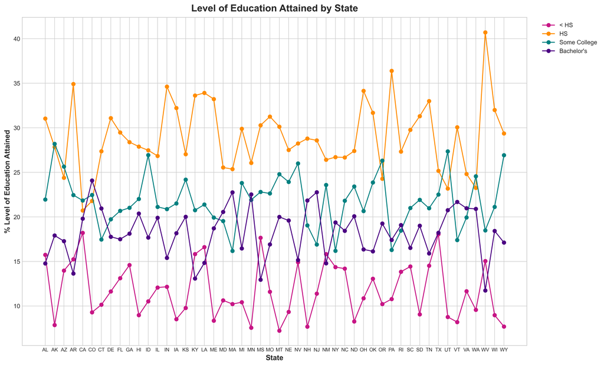

```python
# lineplot to visualize educational attainment by state

plt.style.use("seaborn-whitegrid") # uses seaborn's whitegrid stylesheet

plt.figure(figsize=(15,10), dpi = 400)
plt.rc(
    "axes",
    labelweight="bold",
    labelsize="large",
    titleweight="bold",
    titlesize=16,
    titlepad=10,
)

plt.rc("xtick",
      labelsize = "small")

# color for each category
color_dict = {'Less': 'mediumvioletred', 'HS': 'darkorange', "SC" : "teal", 'Bach': 'indigo'}

# plot 4 lines, corresponding to the 4 relevant columns from the data
plt.plot(state_data['Abbrev'], state_data['% Less Than HS'],
         marker='o',linestyle='-', color=color_dict['Less'], label='< HS')
plt.plot(state_data['Abbrev'], state_data['% HS'],
         marker='o',linestyle='-', color=color_dict['HS'], label='HS')
plt.plot(state_data['Abbrev'], state_data['% Some College'],
         marker='o',linestyle='-', color=color_dict['SC'], label='Some College')
plt.plot(state_data['Abbrev'], state_data["% Bachelor's"],
         marker='o',linestyle='-', color=color_dict['Bach'], label="Bachelor's")

plt.legend(bbox_to_anchor=(1.15, 1))
plt.ylabel("% Level of Education Attained")
plt.xlabel("State")
plt.title("Level of Education Attained by State")
plt.show();
```

From our visualization, we can see that for almost every state, high school is the highest level of education attained. There are some interesting things to point out, though. There are some states, such as Colorado and Arizona that have Bachelor's degrees and Some College (respectively) as their highest level of education. The state with the highest percentage of High School completion is West Virginia, which is interesting because at the same time, West Virginia has the lowest percentage of Bachelor's degrees. This makes sense; as one category increases the others should decrease.

California may be an outlier in this regard because they have the lowest percentage of High School completion, but their other categories are quite mediocre. It should be expected that since their High School completion is low, that their secondary education percentages are among the higher percentages, but this is not the case. In fact, their percentage of less than High School completion is quite high as well.

All of this put together may be somewhat concerning and would be something worth looking into for the education system in California.

### A Regional Comparison

The last perspective we will be looking at unemployment and educational through will be regional. We will divide the United States up into four regions, according to the U.S. Census Bureau's regional divisions.<sup>9</sup>

The four regions are:

- Northeast: Connecticut, Maine, Massachusetts, New Hampshire, Rhode Island, Vermont, New Jersey, New York, and Pennsylvania
- Midwest: Illinois, Indiana, Michigan, Ohio, Wisconsin, Iowa, Kansas, Minnesota, Missouri, Nebraska, North Dakota, and South Dakota
- South: Delaware, Florida, Georgia, Maryland, North Carolina, South Carolina, Virginia, West Virginia, Alabama, Kentucky, Mississippi, Tennessee, Arkansas, Louisiana, Oklahoma, and Texas
- West: Arizona, Colorado, Idaho, Montana, Nevada, New Mexico, Utah, Wyoming, Alaska, California, Hawaii, Oregon, and Washington

As a reminder, we took the District of Columbia and Puerto Rico out of consideration.

```python
# Define states in each region
# Northeast
NE = ["Connecticut", "Maine", "Massachusetts", "New Hampshire", "Rhode Island",
      "Vermont", "New Jersey", "New York", "Pennsylvania"]
# Midwest
MW = ["Illinois", "Indiana", "Michigan", "Ohio", "Wisconsin", "Iowa", "Kansas",
      "Minnesota", "Missouri", "Nebraska", "North Dakota", "South Dakota"]
# South
S = ["Delaware", "Florida", "Georgia", "Maryland", "North Carolina", "South Carolina",
     "Virginia", "West Virginia", "Alabama", "Kentucky", "Mississippi", "Tennessee",
     "Arkansas", "Louisiana", "Oklahoma", "Texas"]
# West
W = ["Arizona", "Colorado", "Idaho", "Montana", "Nevada", "New Mexico", "Utah",
     "Wyoming", "Alaska", "California", "Hawaii", "Oregon", "Washington"]
```

```python
# Split df into 4 by region as defined above
NE_states = state_data.loc[state_data["state"].isin(NE)].reset_index(drop = True)
MW_states = state_data.loc[state_data["state"].isin(MW)].reset_index(drop = True)
S_states = state_data.loc[state_data["state"].isin(S)].reset_index(drop = True)
W_states = state_data.loc[state_data["state"].isin(W)].reset_index(drop = True)

# Check - should sum to 50
print(NE_states.shape[0] + MW_states.shape[0] + W_states.shape[0] + S_states.shape[0])
```

```
50
```

```python
# df of means
means_by_region = pd.DataFrame({"NE States": NE_states.mean(), "MW States": MW_states.mean(),
                                "S States": S_states.mean(), "W States": W_states.mean()})
means_by_region
```

|  | NE States | MW States | S States | W States |
| --- | --- | --- | --- | --- |
| % Unemployed | 7.549101 | 6.435891 | 8.327391 | 7.763538 |
| % Less Than HS | 10.551472 | 9.884656 | 14.502123 | 11.003183 |
| % HS | 29.316513 | 30.025496 | 30.633887 | 25.768390 |
| % Some College | 17.540965 | 22.258256 | 21.183252 | 25.127573 |
| % Associate's | 8.210530 | 9.518842 | 7.398310 | 8.794055 |
| % Bachelor's | 20.512209 | 18.571141 | 16.322938 | 18.854112 |
| % Master's | 9.940536 | 6.970143 | 7.074063 | 7.325890 |
| % Doctor's | 1.625944 | 1.133488 | 1.200554 | 1.318400 |

We will also be using a heatmap to visualize the differences, as a plain dataframe is not only boring, but also not as clear in showing the values.

```python
# Function to calculate the difference in means of a column between two dataframes
def comp_means(d1, d2):
    diffs = {}
    for i in range(len(d1)):
        diffs[d1.index[i]] = (d1[i] - d2[i])
    return diffs
```

```python
# df of mean comparisons for each region
mean_diffs = pd.DataFrame(
    [pd.Series(comp_means(NE_states.mean(), MW_states.mean()), name = "NE States vs. MW States"),
    pd.Series(comp_means(NE_states.mean(), S_states.mean()), name = "NE States vs. S States"),
    pd.Series(comp_means(NE_states.mean(), W_states.mean()), name = "NE States vs. W States"),
    pd.Series(comp_means(MW_states.mean(), S_states.mean()), name = "MW States vs. S States"),
    pd.Series(comp_means(MW_states.mean(), W_states.mean()), name = "MW States vs. W States"),
    pd.Series(comp_means(S_states.mean(), W_states.mean()), name = "S States vs. W States")]
)

mean_diffs
```

|  | % Unemployed | % Less Than HS | % HS | % Some College | % Associate's | % Bachelor's | % Master's | % Doctor's |
| --- | --- | --- | --- | --- | --- | --- | --- | --- |
| NE States vs. MW States | 1.113210 | 0.666816 | -0.708983 | -4.717291 | -1.308311 | 1.941068 | 2.970393 | 0.492456 |
| NE States vs. S States | -0.778291 | -3.950651 | -1.317374 | -3.642287 | 0.812221 | 4.189272 | 2.866473 | 0.425391 |
| NE States vs. W States | -0.214437 | -0.451711 | 3.548123 | -7.586609 | -0.583524 | 1.658097 | 2.614646 | 0.307545 |
| MW States vs. S States | -1.891500 | -4.617467 | -0.608391 | 1.075004 | 2.120532 | 2.248204 | -0.103920 | -0.067065 |
| MW States vs. W States | -1.327647 | -1.118527 | 4.257106 | -2.869317 | 0.724787 | -0.282971 | -0.355747 | -0.184911 |
| S States vs. W States | 0.563853 | 3.498940 | 4.865498 | -3.944321 | -1.395745 | -2.531175 | -0.251827 | -0.117846 |

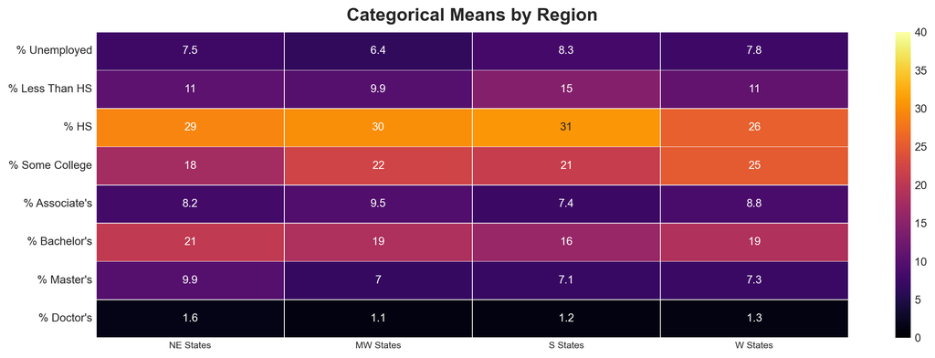

```python
# Heatmap of regional means
plt.figure(figsize=(15, 5), dpi = 200)
sns.heatmap(means_by_region, vmin=0, vmax=40, cmap = "inferno", annot = True, linewidth=0.25)
plt.title("Categorical Means by Region");
```

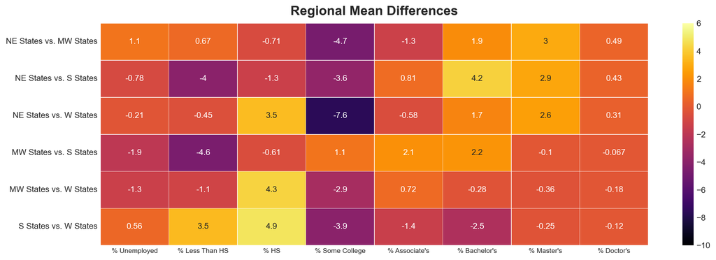

```python
# Heatmap of differences
plt.figure(figsize=(15, 5), dpi = 200)
sns.heatmap(mean_diffs, vmin=-10, vmax=6, cmap = "inferno", annot = True, linewidth=0.25)
plt.title("Regional Mean Differences");
```

The differences look very tame at first glance, but what pops out is the fact that for the `% HS` category, each of the other 3 regions have a higher average than states in the West. At the same time, for the `% Some College` category, the West has a higher average than the 3 other regions.

Additionally, we had an idea that states in the Midwest had lower rates of unemployment, and that is supported by the fact that, on average, the Midwest had a lower percent of unemployment compared to the other 3 regions and also had lower rates of `Less Than HS` completion.

This would seem to add to our intuition that, at least regionally, there is some educational disparity that is rippling to affect employment outcomes.

## Conclusions

It would seem like we have done a lot to look at educational attainment and employment outcome at the state level, but in reality we have only barely scratched the surface.

In regards to our expectations, California went against what we expected and was an outlier in this sense. Their High School completion is the lowest of all states but their secondary education is not as high as we would expect it to be. It would be interesting to look into what factors are causing this in California and see if there is an issue in their educational system.

As was previously mentioned, this is only the tip of the iceberg and there are so many other ways educational disparity could be measured and examined. For further research, we could bring in some extra dimensionality to help determine if there really is a difference in educational attainment between states and it would give insight into what should be done about it, if the difference is significant. Other variables we could look into include income, poverty rates, race/ethnicity, and also population. Future research could also determine which states are displaying a significant gap in education compared to other states, which could take us into the direction of narrowing down the scope of research and identifying what factors within that state give rise to its gap.

## References

<sup>1</sup> U.S. Census Bureau FAQ. Accessed on March 7, 2023, from https://www.census.gov/data/what-is-data-census-gov/guidance-for-data-users/frequently-asked-questions.html

<sup>2</sup> Introduction to the American Community Survey. Accessed on March 12, 2023, from https://www.census.gov/data/academy/webinars/2022/introduction-to-the-american-community-survey.html

<sup>3</sup> CensusData Documentation. Accessed on March 14, 2023, from https://jtleider.github.io/censusdata/index.html

<sup>4</sup> Variables in the ACS. Accessed on March 12, 2023, from https://jtleider.github.io/censusdata/variables.html#american-community-survey-1-3-and-5-year-estimates

<sup>5</sup> Subject Tables. Accessed on March 12, 2023, from https://www.census.gov/acs/www/data/data-tables-and-tools/subject-tables/

<sup>6</sup> List of U.S. Cities by Population. Accessed on March 17, 2023. From https://en.wikipedia.org/wiki/List_of_United_States_cities_by_population

<sup>7</sup> Mann-Whitney U Test. Wikipedia. Accessed on March 18, 2023, from https://en.wikipedia.org/wiki/Mann%E2%80%93Whitney_U_test

<sup>8</sup> Scipy Mann-Whitney U. Accessed on March 18, 2023, from https://docs.scipy.org/doc/scipy/reference/generated/scipy.stats.mannwhitneyu.html

<sup>9</sup> U.S. Census Regions. U.S. Census Bureau. Accessed on March 18, 2023, from https://www2.census.gov/geo/pdfs/maps-data/maps/reference/us_regdiv.pdf.

<sup>10</sup> Pearson Correlation Coefficient. Accessed on March 19, 2023, from https://en.wikipedia.org/wiki/Pearson_correlation_coefficient

## Appendix - Code

```python
import pandas as pd
import censusdata as cd
import seaborn as sns
import regex as re
import plotly.express as px
import plotly.offline as ofl
import matplotlib.pyplot as plt
import scipy

# Example

# Look at table containing certain variables related to one label
cd.printtable(cd.censustable("acs5", 2015, "B23025"))

# Select one or more of the variables to download tables for, based on geographic level
example = cd.download("acs5", 2015, cd.censusgeo([("state", "*")]), ["B23025_003E"])
example.rename(columns={"B23025_003E" : "number_unemployed"}).head()

# Table indices are reduced to state or county name, then transformed into corresponding column
def process_table(table, geo_level):
    table = table.reset_index().copy()
    info = table["index"]
    names = []

    if geo_level.lower() == "state":
        for i in info:
            names.append(i.name)
    elif geo_level.lower() == "county":
        for i in info:
            names.append(re.split('(.+?(County))', i.name)[1])
    else:
        raise Exception("Select only state or county level data")

    table.iloc[:, 0] = names
    table = table.rename(columns = {"index": f"{geo_level}"})
    table = table.sort_values(by = [f"{geo_level}"]).reset_index().drop(columns = ["index"])
    return table

# Unemployment numbers (total workforce, number unemployed)
# Uncomment below lines to double check, but printing looks unclean

#cd.printtable(cd.censustable('acs5', 2015, 'B23025'))

# Level of education obtained (K-12 (less than HS), HS, Some College, Associate's, Bachelor's, Master's, Doctoral)

# cd.printtable(cd.censustable('acs5', 2015, 'B15003'))

# Downloads the above
states = cd.download('acs5', 2015, cd.censusgeo([('state', '*')]),
                 ['B15003_002E', 'B15003_003E','B15003_004E', 'B15003_005E', 'B15003_006E',
                  'B15003_007E', 'B15003_008E', 'B15003_009E', 'B15003_010E', 'B15003_011E', 'B15003_012E',
                  'B15003_013E', 'B15003_014E', 'B15003_015E', 'B15003_016E', "B23025_003E", "B23025_005E",
                  "B15003_017E", "B15003_018E", "B15003_019E", "B15003_020E", "B15003_021E", "B15003_022E",
                  "B15003_023E", "B15003_024E", "B15003_025E", "B15003_001E"])

# Unemployment % by dividing num. unemployed by total labor force
states["% Unemployed"] = states.B23025_005E / states.B23025_003E * 100

# Sum completion of schooling, less than HS completion to get percentage
states["% Less Than HS"] = states.iloc[:, :15].sum(axis=1) / states.B15003_001E * 100

states["% HS"] = (states.B15003_017E + states.B15003_018E) / states.B15003_001E * 100 # HS or GED in one category

states["% Some College"] = (states.B15003_019E + states.B15003_020E) / states.B15003_001E * 100 # Some college completed

states["% Associate's"] = (states.B15003_021E) / states.B15003_001E * 100 # Associate's

states["% Bachelor's"] = (states.B15003_022E) / states.B15003_001E * 100 # Bachelor's

states["% Master's"] = (states.B15003_023E) / states.B15003_001E * 100 # Master's

states["% Doctor's"] = (states.B15003_025E) / states.B15003_001E * 100 # Doctorate

# Combine all into a single dataframe
state_data = states[["% Unemployed", "% Less Than HS", "% HS",
                     "% Some College", "% Associate's", "% Bachelor's",
                     "% Master's", "% Doctor's"]]

# Processes dataframe to extract state names as column
state_data = process_table(state_data, "state")

# Check if it worked
state_data.head()

# Drop D.C. and Puerto Rico
state_data = state_data.drop([8, 39]).reset_index(drop = True)

# Add column of state abbreviations
state_data.insert(1, "Abbrev", ["AL", "AK", "AZ", "AR", "CA", "CO", "CT", "DE", "FL", "GA",
                  "HI", "ID", "IL", "IN", "IA", "KS", "KY", "LA", "ME", "MD", "MA", "MI",
                  "MN", "MS", "MO", "MT", "NE", "NV", "NH", "NJ", "NM", "NY", "NC",
                  "ND", "OH", "OK", "OR", "PA", "RI", "SC", "SD", "TN", "TX", "UT",
                  "VT", "VA", "WA", "WV", "WI", "WY"])

state_data.head()

state_data.describe() # summary of data

state_data.corr() # pearson corr coefficient of each column

# Heatmap of unemployment using map of the United States
fig = px.choropleth(state_data,  # dataframe input
                    locations="Abbrev",  # locations
                    color="% Unemployed",  # determines color values
                    color_continuous_scale="plasma",
                    hover_name="state", # hover info
                    scope = "usa", # the map displayed
                    locationmode = 'USA-states') # plots US States

fig.update_layout(
    title_text = 'Unemployment by State', # Add a title to plot
    geo_scope="usa",  # Plot only the USA instead of globe
)
ofl.iplot(fig)

# top 5, bottom 5 states for unemployment
top = state_data.sort_values("% Unemployed", ascending = False)[:5]
bot = state_data.sort_values("% Unemployed", ascending = True)[:5]
topbot = top.append(bot)
topbot

unemp_mean = state_data.mean()["% Unemployed"] # Mean unemployment rate
print(f"The mean unemployment rate is {unemp_mean}")

# find number of states with larger unemployment rate than the mean
print(f"{sum(state_data['% Unemployed'] >= unemp_mean)} states have an unemployment rate larger than this")

# Compare average unemployment of top 5 with bottom 5
mean_diff = top["% Unemployed"].mean() - bot["% Unemployed"].mean()
print(f"The top 5 states have mean unemployment % {top['% Unemployed'].mean()}")
print(f"The bottom 5 states have mean unemployment % {bot['% Unemployed'].mean()}")
print(f"The difference in mean unemployment % between the top 5 and bottom 5 are {mean_diff}")

# hypothesis test using mann-whitney u
pval_mannwhitneyu = scipy.stats.mannwhitneyu(top["% Unemployed"], bot["% Unemployed"]).pvalue
print(f"Result of hypothesis test: p-val = {pval_mannwhitneyu}")

# look at top 5 and bottom 5 again
topbot

# store means of each category as df
pd.DataFrame([top.mean(), bot.mean()], index = ("Top 5", "Bot 5"))

# lineplot to visualize educational attainment by state

plt.style.use("seaborn-whitegrid") # uses seaborn's whitegrid stylesheet

plt.figure(figsize=(15,10), dpi = 400)
plt.rc(
    "axes",
    labelweight="bold",
    labelsize="large",
    titleweight="bold",
    titlesize=16,
    titlepad=10,
)

plt.rc("xtick",
      labelsize = "small")

# color for each category
color_dict = {'Less': 'mediumvioletred', 'HS': 'darkorange', "SC" : "teal", 'Bach': 'indigo'}

# plot 4 lines, corresponding to the 4 relevant columns from the data
plt.plot(state_data['Abbrev'], state_data['% Less Than HS'],
         marker='o',linestyle='-', color=color_dict['Less'], label='< HS')
plt.plot(state_data['Abbrev'], state_data['% HS'],
         marker='o',linestyle='-', color=color_dict['HS'], label='HS')
plt.plot(state_data['Abbrev'], state_data['% Some College'],
         marker='o',linestyle='-', color=color_dict['SC'], label='Some College')
plt.plot(state_data['Abbrev'], state_data["% Bachelor's"],
         marker='o',linestyle='-', color=color_dict['Bach'], label="Bachelor's")

plt.legend(bbox_to_anchor=(1.15, 1))
plt.ylabel("% Level of Education Attained")
plt.xlabel("State")
plt.title("Level of Education Attained by State")
plt.show();

# Define states in each region
# Northeast
NE = ["Connecticut", "Maine", "Massachusetts", "New Hampshire", "Rhode Island",
      "Vermont", "New Jersey", "New York", "Pennsylvania"]
# Midwest
MW = ["Illinois", "Indiana", "Michigan", "Ohio", "Wisconsin", "Iowa", "Kansas",
      "Minnesota", "Missouri", "Nebraska", "North Dakota", "South Dakota"]
# South
S = ["Delaware", "Florida", "Georgia", "Maryland", "North Carolina", "South Carolina",
     "Virginia", "West Virginia", "Alabama", "Kentucky", "Mississippi", "Tennessee",
     "Arkansas", "Louisiana", "Oklahoma", "Texas"]
# West
W = ["Arizona", "Colorado", "Idaho", "Montana", "Nevada", "New Mexico", "Utah",
     "Wyoming", "Alaska", "California", "Hawaii", "Oregon", "Washington"]

# Split df into 4 by region as defined above
NE_states = state_data.loc[state_data["state"].isin(NE)].reset_index(drop = True)
MW_states = state_data.loc[state_data["state"].isin(MW)].reset_index(drop = True)
S_states = state_data.loc[state_data["state"].isin(S)].reset_index(drop = True)
W_states = state_data.loc[state_data["state"].isin(W)].reset_index(drop = True)

# Check - should sum to 50
print(NE_states.shape[0] + MW_states.shape[0] + W_states.shape[0] + S_states.shape[0])

# df of means
means_by_region = pd.DataFrame({"NE States": NE_states.mean(), "MW States": MW_states.mean(),
                                "S States": S_states.mean(), "W States": W_states.mean()})
means_by_region

# Function to calculate the difference in means of a column between two dataframes
def comp_means(d1, d2):
    diffs = {}
    for i in range(len(d1)):
        diffs[d1.index[i]] = (d1[i] - d2[i])
    return diffs

# df of mean comparisons for each region
mean_diffs = pd.DataFrame(
    [pd.Series(comp_means(NE_states.mean(), MW_states.mean()), name = "NE States vs. MW States"),
    pd.Series(comp_means(NE_states.mean(), S_states.mean()), name = "NE States vs. S States"),
    pd.Series(comp_means(NE_states.mean(), W_states.mean()), name = "NE States vs. W States"),
    pd.Series(comp_means(MW_states.mean(), S_states.mean()), name = "MW States vs. S States"),
    pd.Series(comp_means(MW_states.mean(), W_states.mean()), name = "MW States vs. W States"),
    pd.Series(comp_means(S_states.mean(), W_states.mean()), name = "S States vs. W States")]
)

mean_diffs

# Heatmap of regional means
plt.figure(figsize=(15, 5), dpi = 200)
sns.heatmap(means_by_region, vmin=0, vmax=40, cmap = "inferno", annot = True, linewidth=0.25)
plt.title("Categorical Means by Region");

# Heatmap of differences
plt.figure(figsize=(15, 5), dpi = 200)
sns.heatmap(mean_diffs, vmin=-10, vmax=6, cmap = "inferno", annot = True, linewidth=0.25)
plt.title("Regional Mean Differences");
```